# README

# firstRepo

## Practice with Git

Check out [this interactive tutorial](https://learngitbranching.js.org/) and complete the first four levels. Once you have done that, recreate this document.

## Markdown

This is example markdown text for our toy repository. Normally this part of the document would contain an abstract, summary or introduction to the material covered in the document. You may find [this cheat sheet](https://github.com/adam-p/markdown-here/wiki/Markdown-Cheatsheet) helpful for recreating this document.

This is a new paragraph with *some text in italics* and some text **bolded**. Here is a table with some of the basic data types in R.

| Type | Description |
| --- | --- |
| `numeric()` | real numbers |
| `integer()` | integer numbers |
| `factor()` | categorical data |
| `character()` | text data |
| `data.frame()` | data frame |

Notice that the R code in the table above (e.g. `numeric()`) is formatted differently than the plain text in the description column. We could have done this as a list instead.

- `numeric()`: real numbers
- `integer()`: integer numbers
- `factor()`: categorical data
  - I don’t usually like factors, but they do have their place. You’ll almost always find character variables easier to work with.
- `chatacter()`: text data
- `data.frame()`: a data set
  - Or you could use data_frame(). I like them better for reasons we will discuss later in the course.

## R code

We can also include R code and graphics:

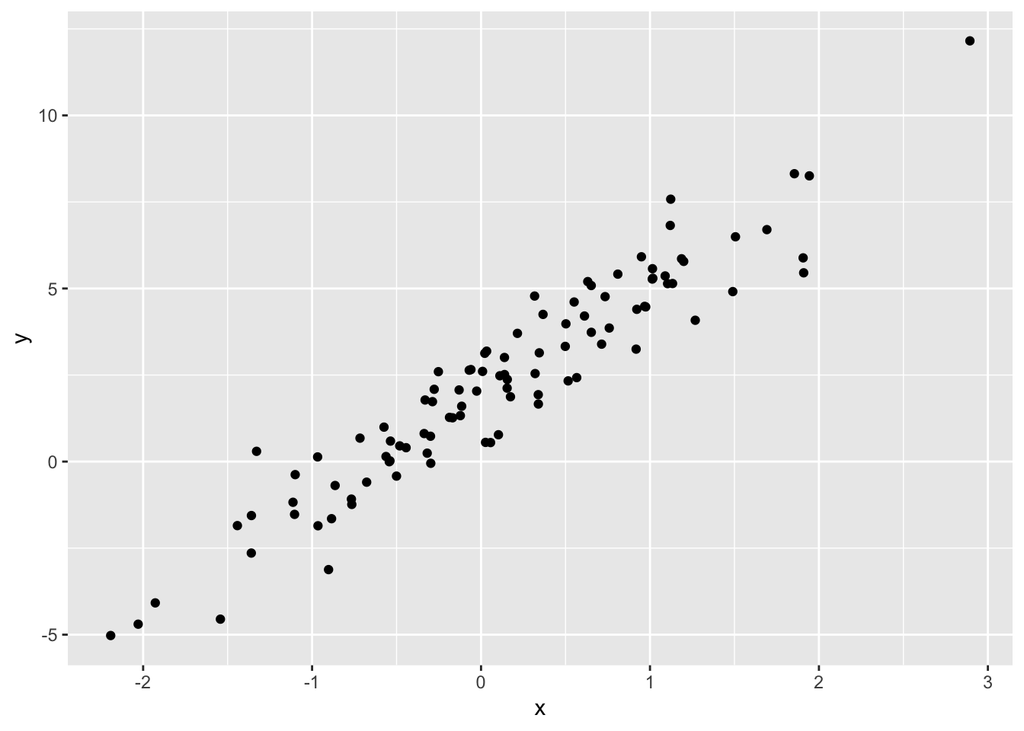

```r
library(tidyverse)
set.seed(273846)

dat <- data_frame(x = rnorm(100),
                  y = 2 + 3*x + rnorm(100))

ggplot(dat, aes(x, y)) +
    geom_point()
```

I don’t like the default settings for `ggplot`. Try making the same figure after loading the `cowplot` package.

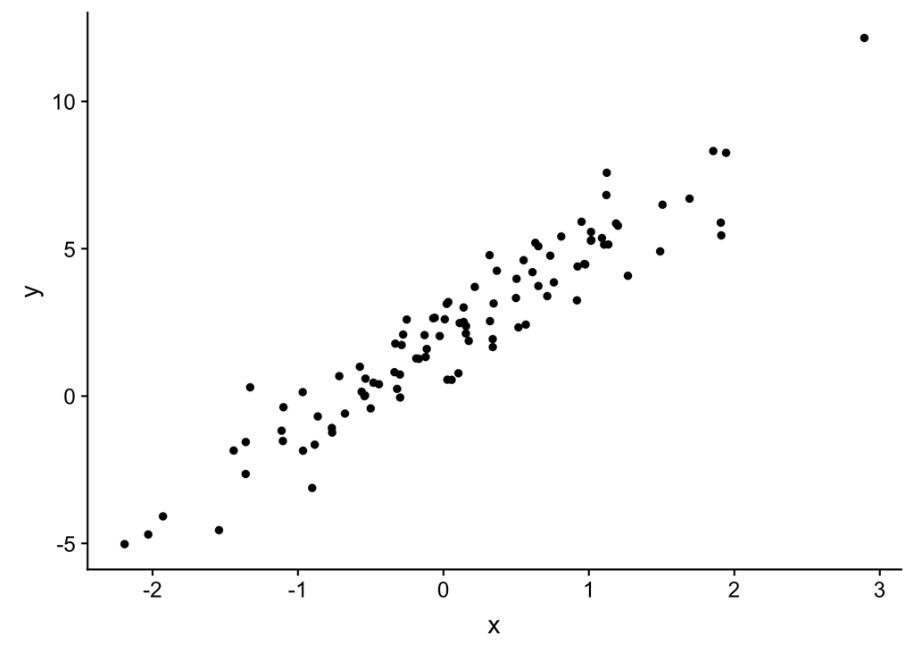

```r
library(cowplot)
ggplot(dat, aes(x, y)) +
    geom_point()
```

## Commit, Push, and Pull

Once you are finished, commit your files, push them to GitHub, and issue a pull request to submit your work.